# BFA6

ta560@scarletmail.rutgers.edu

11/14/2022

```r
library(fpp)
library(fpp2)
library(forecast)
```

## Data set - usmelec (fpp)

#### usmelec plot

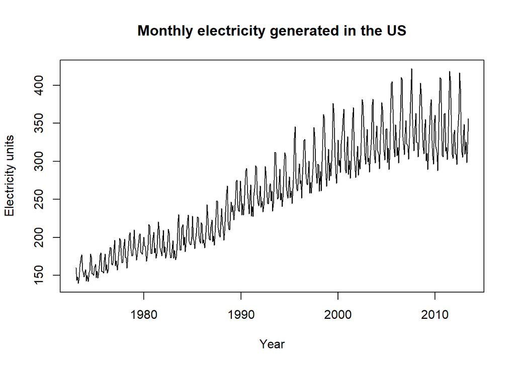

```r
plot(usmelec, main = 'Monthly electricity generated in the US', xlab = 'Year', ylab = 'Electricity units')
```

- Trend and Seasonality can be seen in the plot.
- There is an increase of residuals when we perform all the tests which indicates that the latest data is different from the past data.
- So,lets consider a window of the data from 2000.

#### Window Plot

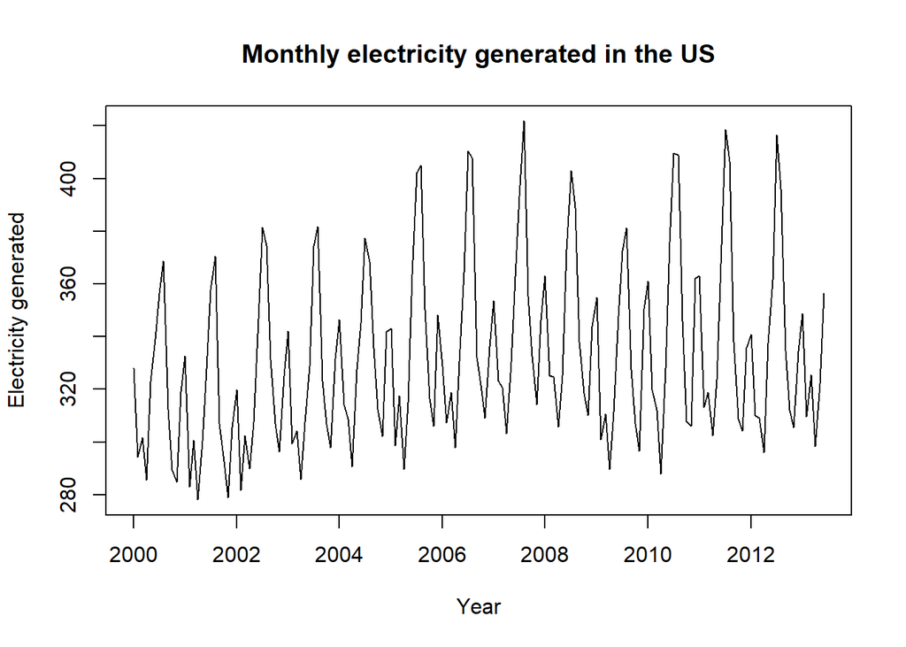

```r
usmelec_win <- window(usmelec, start = 2000)
plot(usmelec_win, main = 'Monthly electricity generated in the US', xlab = 'Year', ylab = 'Electricity generated')
```

- Even here, we can observe both trend and seasonality from the first glance.
- Lets do an Acf function.

#### Acf plot

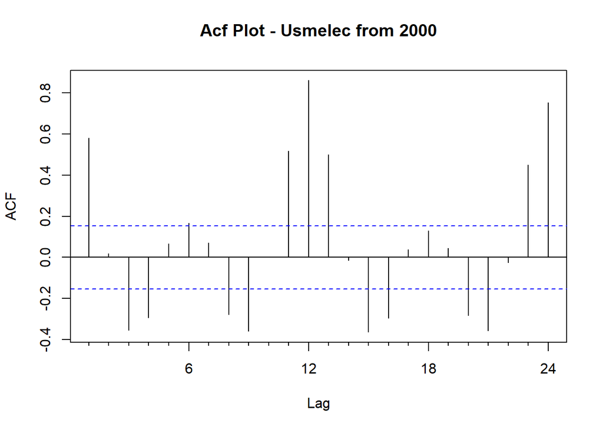

```r
Acf(usmelec_win, main = 'Acf Plot - Usmelec from 2000')
```

- The Acf plot shows both trend and seasonality present in the plot.
- Since there is seasonality we use both nsdiffs and ndiffs.

## ARIMA for data with seasonal component

#### Checking the Differencing needed for seasonal component

```r
nsdiffs(usmelec_win) #nsdiffs is for seasonal
```

```
## [1] 1
```

- nsdiffs is use to know how many differences we need to do for seasonality component.
- We first go ahead with seasonality beacuse most of the cases, ones we do this, trend takes care of itself.

#### Checking the Differences needed

```r
ndiffs(usmelec_win)
```

```
## [1] 1
```

- We got ndiffs as 1 initially.
- Let us first perform the differences for seasonal data and check ndiffs again.

#### Rechecking the differencing needed after performing the seasonal differencing

```r
ndiffs((diff(usmelec_win,12))) #12 because it is monthly
```

```
## [1] 0
```

- As mentioned above, we can see that the ndiffs now becomes zero indicating that the trend component took care of itself.

#### Acf and Pacf plots

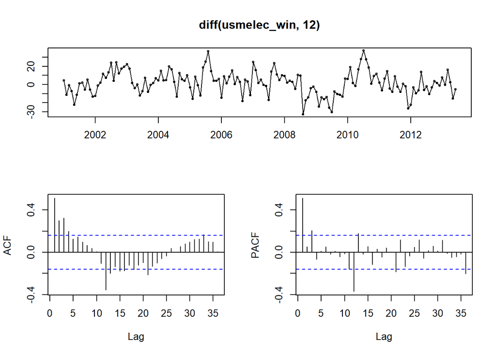

```r
tsdisplay(diff(usmelec_win,12))
```

- In the Acf plot we can see that the p value is 11.

#### Arima Model

```r
arima_fit <- auto.arima(usmelec_win,trace=TRUE, stepwise = FALSE )
```

```
##
##  Fitting models using approximations to speed things up...
##
##  ARIMA(0,0,0)(0,1,0)[12]                    : 1134.244
##  ARIMA(0,0,0)(0,1,0)[12] with drift         : 1133.629
##  ARIMA(0,0,0)(0,1,1)[12]                    : 1114.441
##  ARIMA(0,0,0)(0,1,1)[12] with drift         : 1102.139
##  ARIMA(0,0,0)(0,1,2)[12]                    : 1116.46
##  ARIMA(0,0,0)(0,1,2)[12] with drift         : 1101.197
##  ARIMA(0,0,0)(1,1,0)[12]                    : 1123.68
##  ARIMA(0,0,0)(1,1,0)[12] with drift         : 1116.602
##  ARIMA(0,0,0)(1,1,1)[12]                    : 1124.567
##  ARIMA(0,0,0)(1,1,1)[12] with drift         : 1113.193
##  ARIMA(0,0,0)(1,1,2)[12]                    : Inf
##  ARIMA(0,0,0)(1,1,2)[12] with drift         : 1105.064
##  ARIMA(0,0,0)(2,1,0)[12]                    : 1119.201
##  ARIMA(0,0,0)(2,1,0)[12] with drift         : 1110.525
##  ARIMA(0,0,0)(2,1,1)[12]                    : 1115.64
##  ARIMA(0,0,0)(2,1,1)[12] with drift         : 1105.265
##  ARIMA(0,0,0)(2,1,2)[12]                    : 1117.765
##  ARIMA(0,0,0)(2,1,2)[12] with drift         : 1104.719
##  ARIMA(0,0,1)(0,1,0)[12]                    : 1096.306
##  ARIMA(0,0,1)(0,1,0)[12] with drift         : 1096.714
##  ARIMA(0,0,1)(0,1,1)[12]                    : 1068.674
##  ARIMA(0,0,1)(0,1,1)[12] with drift         : 1058.331
##  ARIMA(0,0,1)(0,1,2)[12]                    : 1070.658
##  ARIMA(0,0,1)(0,1,2)[12] with drift         : 1057.836
##  ARIMA(0,0,1)(1,1,0)[12]                    : 1079.086
##  ARIMA(0,0,1)(1,1,0)[12] with drift         : 1075.874
##  ARIMA(0,0,1)(1,1,1)[12]                    : 1079.71
##  ARIMA(0,0,1)(1,1,1)[12] with drift         : 1072.985
##  ARIMA(0,0,1)(1,1,2)[12]                    : Inf
##  ARIMA(0,0,1)(1,1,2)[12] with drift         : 1064.628
##  ARIMA(0,0,1)(2,1,0)[12]                    : 1076.782
##  ARIMA(0,0,1)(2,1,0)[12] with drift         : 1072.277
##  ARIMA(0,0,1)(2,1,1)[12]                    : 1073.674
##  ARIMA(0,0,1)(2,1,1)[12] with drift         : 1064.569
##  ARIMA(0,0,1)(2,1,2)[12]                    : 1072.529
##  ARIMA(0,0,1)(2,1,2)[12] with drift         : Inf
##  ARIMA(0,0,2)(0,1,0)[12]                    : 1096.527
```

[output cut: 147 more lines]

```
##  ARIMA(4,0,0)(0,1,1)[12]                    : 1050.557
##  ARIMA(4,0,0)(0,1,1)[12] with drift         : 1048.7
##  ARIMA(4,0,0)(1,1,0)[12]                    : 1065.085
##  ARIMA(4,0,0)(1,1,0)[12] with drift         : 1065.68
##  ARIMA(4,0,1)(0,1,0)[12]                    : 1090.462
##  ARIMA(4,0,1)(0,1,0)[12] with drift         : 1091.625
##  ARIMA(5,0,0)(0,1,0)[12]                    : 1089.73
##  ARIMA(5,0,0)(0,1,0)[12] with drift         : 1091.008
##
##  Now re-fitting the best model(s) without approximations...
##
##
##
##
##  Best model: ARIMA(1,0,2)(0,1,1)[12]
```

```r
arima_fit
```

```
## Series: usmelec_win
## ARIMA(1,0,2)(0,1,1)[12]
##
## Coefficients:
##          ar1      ma1      ma2     sma1
##       0.9717  -0.4381  -0.2695  -0.8089
## s.e.  0.0304   0.0857   0.0923   0.0913
##
## sigma^2 = 80.44:  log likelihood = -546.02
## AIC=1102.04   AICc=1102.46   BIC=1117.09
```

- The system runs the auto arima and gives out the best model for which the AIC value is the lowest.AIC value is 1102.04 from the arima function.
- The model tested multiple p,q,P,Q values other than the ones we predicted earlier.

#### Arima Model attributes

```r
attributes(arima_fit)
```

```
## $names
##  [1] "coef"      "sigma2"    "var.coef"  "mask"      "loglik"    "aic"
##  [7] "arma"      "residuals" "call"      "series"    "code"      "n.cond"
## [13] "nobs"      "model"     "bic"       "aicc"      "x"         "fitted"
##
## $class
## [1] "forecast_ARIMA" "ARIMA"          "Arima"
```

#### Plot the forecast of the Arima model with confidence interval of 99%

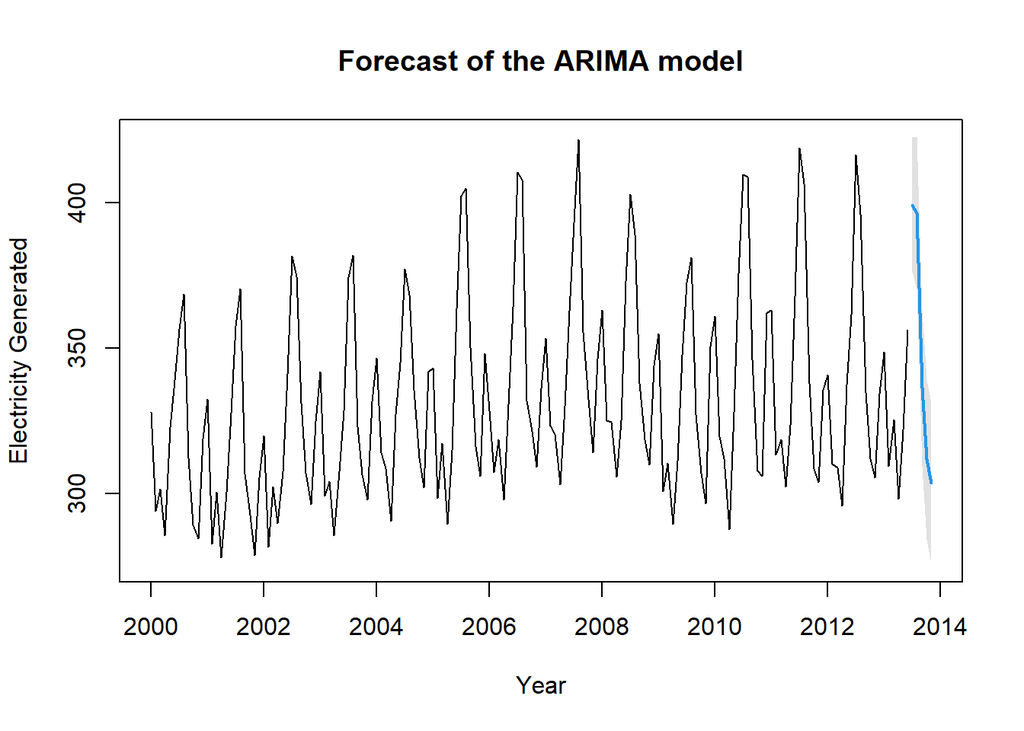

```r
plot(forecast(arima_fit,h=5,level=c(99)), main = 'Forecast of the ARIMA model', xlab = 'Year', ylab = 'Electricity Generated')
```

## Residual Analysis

#### Acf of Residuals

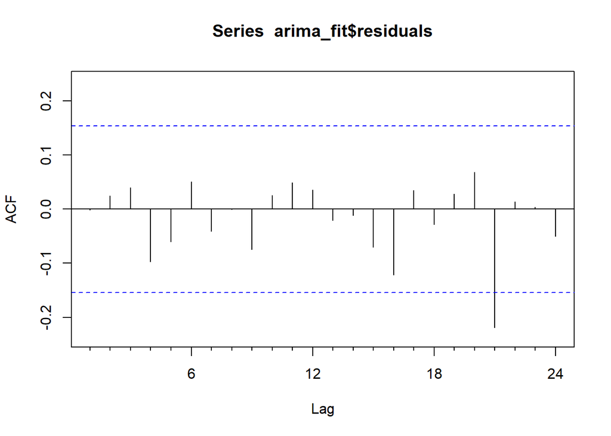

```r
Acf(arima_fit$residuals)
```

#### Box-Ljung test

```r
Box.test(residuals(arima_fit), lag=20, type="Ljung")
```

```
##
##  Box-Ljung test
##
## data:  residuals(arima_fit)
## X-squared = 10.085, df = 20, p-value = 0.9666
```

- We got p-value 0.9666 which is greater than 0.05 means that the null hypothesis is true

#### Residuals plot

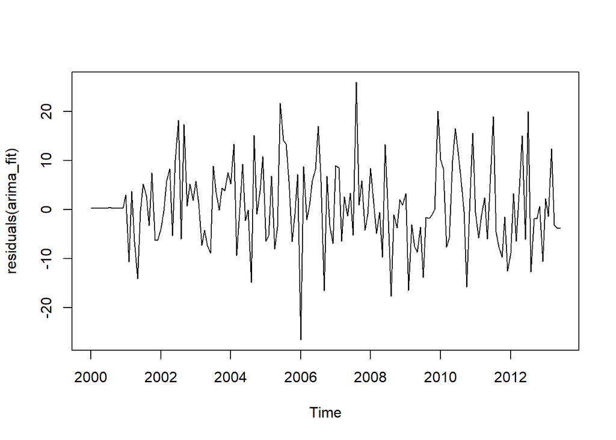

```r
plot.ts(residuals(arima_fit))
```

- The residuals look random and mean to be around zero.
- This means its a very good forecasting model.

#### Histogram plot of residuals

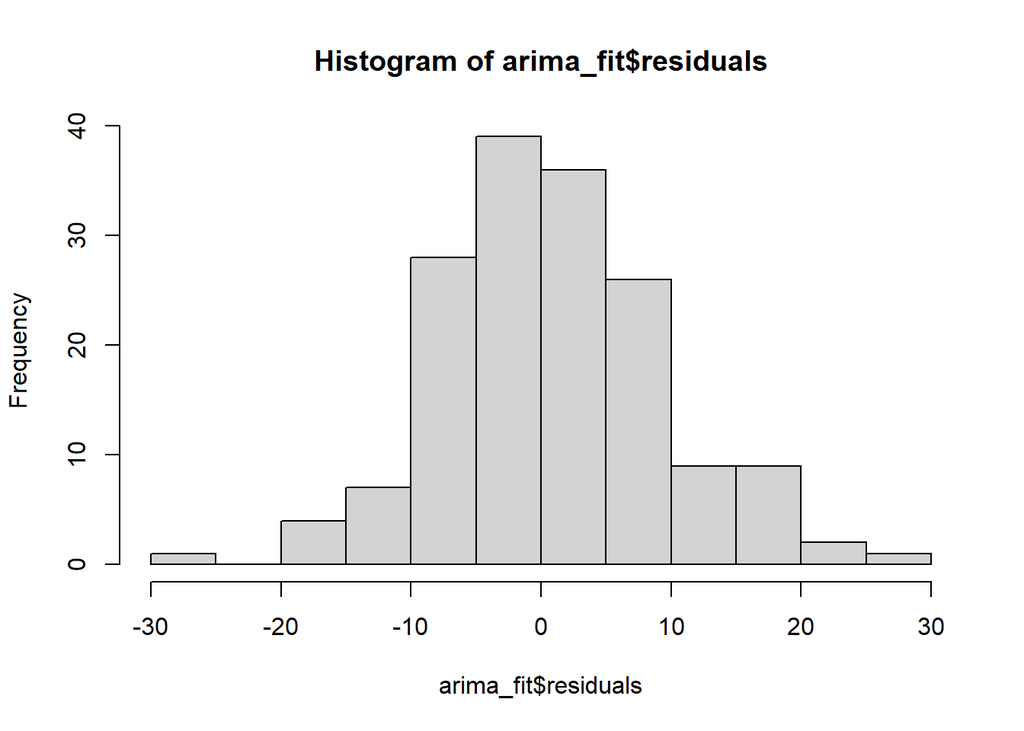

```r
hist(arima_fit$residuals)
```

- The histogram above shows residuals have a mean around zero.
- This distribution does not look like a perfect normal distribution.

#### TSDiagram of the ARIMA model

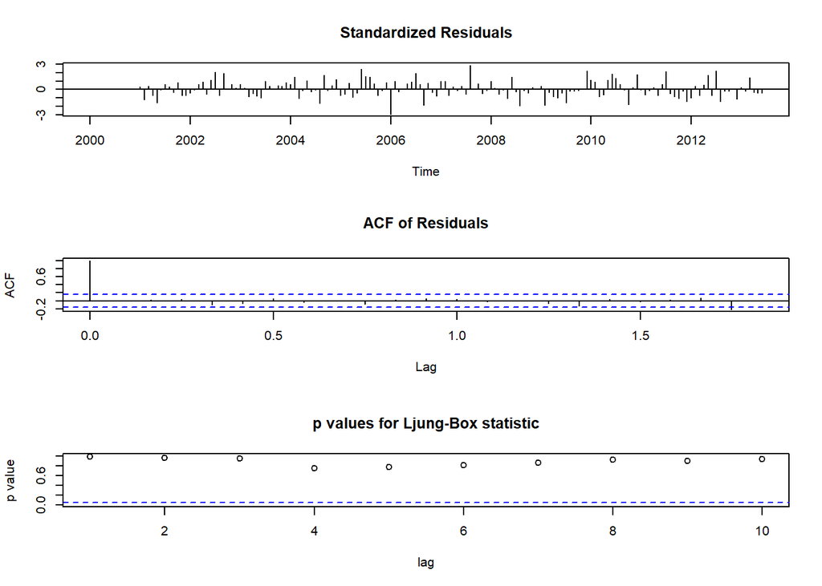

```r
tsdiag(arima_fit)
```